# EDA - Wk1

MCCurcio

12/22/2020

# Principles of Analytic Graphics

## Rules for building analytical graphics

See: https://github.com/DataScienceSpecialization

See: “Beautiful Evidence”, Edward Tufte

[Coursera1](https://www.coursera.org/learn/exploratory-data-analysis/lecture/o967b/principles-of-analytic-graphics)

1. Show Comparisons;
   - Evidence is always relative to other competing ideas and hypothesis.
   - Always ask, **“Compared to What?”**
   - Compared to Controls vs Treatment…
2. Show causality, mechanisms, explanations, systematic structure(s)
   - What is your causality framework for thinking about the question/situation.
   - Q. How do you think the world is working?
   - Example given by R.P. is symptom free days vs fine particulates in air.
3. Show multivariate data
   - the real world is multivariate
   - Therefore **show as much data on a single plot as you can**
   - Too much data can dilute or confound the message while distributing the data over a variable may show a different function.
   - **Simpson’s paradox**

> The [Yule–Simpson effect](http://en.wikipedia.org/wiki/Simpson%27s_paradox) tells us that this “is a paradox in probability and statistics, in which a trend that appears in different groups of data disappears when these groups are combined.”
4. Integrate the evidence
   - Completely integrate words, numbers, images, diagrams
   - *Combine different modes of info into one graphic!*
   - Data graphics should make use of many modes of data presentation
   - Don’t let the tool drive the analysis, make you want…
5. Describe & document the evidence with appropriate labels, scales, sources, etc.
   - A graphic should tell a **complete** story that is credible.
   - What was the data source?
   - Document the computer code that made the plot TOO!
6. Content is King
   - Analytical presentations ultimately stand or fall depending on the quality, relevance and integrity of their content.

## Exploratory Graphs-Part 1

[Coursera2](https://www.coursera.org/learn/exploratory-data-analysis/lecture/ilRAK/exploratory-graphs-part-1)

- Slides for this and other Data Science courses may be found at:
  - https://github.com/DataScienceSpecialization/courses/
- If you care to use them, they must be downloaded as a zip file and viewed locally.
- This lesson corresponds to `04_ExploratoryAnalysis/exploratoryGraphs`.

### Graphics for “internal use”

1. Why use a graphic?
   - Understand properties
   - Find patterns in data
   - Suggest models strategies
   - ‘Debug’ analyses
   - Communicate results
2. Exploratory graphics can be:
   - Made quickly
   - Made in large numbers
   - Are there problems?
   - **Goal is for personal understanding**
   - Axes and legends are generally cleaned later!
   - Color and size are primarily used for info.
3. Common plots and summaries
   - **1D**
   - 5-number summaries
   - Boxplots
   - Histograms
   - Density plots
   - Barplots

## Exploratory Graphs-Part 2

[Coursera3](https://www.coursera.org/learn/exploratory-data-analysis/lecture/ilRAK/exploratory-graphs-part-2)

4. Summaries of Data
   - **2D**
   - Multiple/overlayed 1-D plots (Lattice/ggplot2)
   - Scatterplots
   - Smooth scatterplots
   - **Greater than 2D**
   - Multiple/overlayed 2-D plots
   - Use color, size, shape to add dimensions
   - Spinning plots
   - Actual 3D plots (usefulness is debatable)

## Base Plotting Systems in R

[Coursera4](https://www.coursera.org/learn/exploratory-data-analysis/lecture/MTRt4/plotting-systems-in-r)

- R has 3 core plotting systems:
1. Base - intuitive model, `plot()`, adjusting margins is difficult
2. Lattice - `library(lattice)`, `xyplot`, `bwplot`…, panel plots
3. Ggplot2 - “grammar of graphics”

See: Interesting article by Jeff Leek, [why-i-dont-use-ggplot2](https://simplystatistics.org/2016/02/11/why-i-dont-use-ggplot2/)

## Base Plotting System-Part 1

[Coursera5](https://www.coursera.org/learn/exploratory-data-analysis/lecture/GhFPB/base-plotting-system-part-1)

### Important Base graphics parameters

- `las` - orientation of labels
- `bg` - background color
- `mar` - margins size
- `oma` - outer margin size (default = 0)
- `mfrow` - number of plots per row (rows filled 1st)
- `mcol` - number of plots per col (cols filed 1st)

Example: `par("mar")` > gives default = [5.1, 4.1, 4.1, 2.1]

## Base Plotting System-Part 2

[Coursera6](https://www.coursera.org/learn/exploratory-data-analysis/lecture/m4P1I/base-plotting-system-part-2)

Basic plotting functions:

```
- plot
- lines
- points
- pch - plot characters; ex. dots, x, squares,...
- title - "main" & "sub"
- mtext - Add text to the margins
- axis - Add ticks to axis
- legend("topright", legend = data, pch = 20)
- abline - lines
- xlab, ylab, xlim, ylim
```

#### EXAMPLE: Multiple base plots

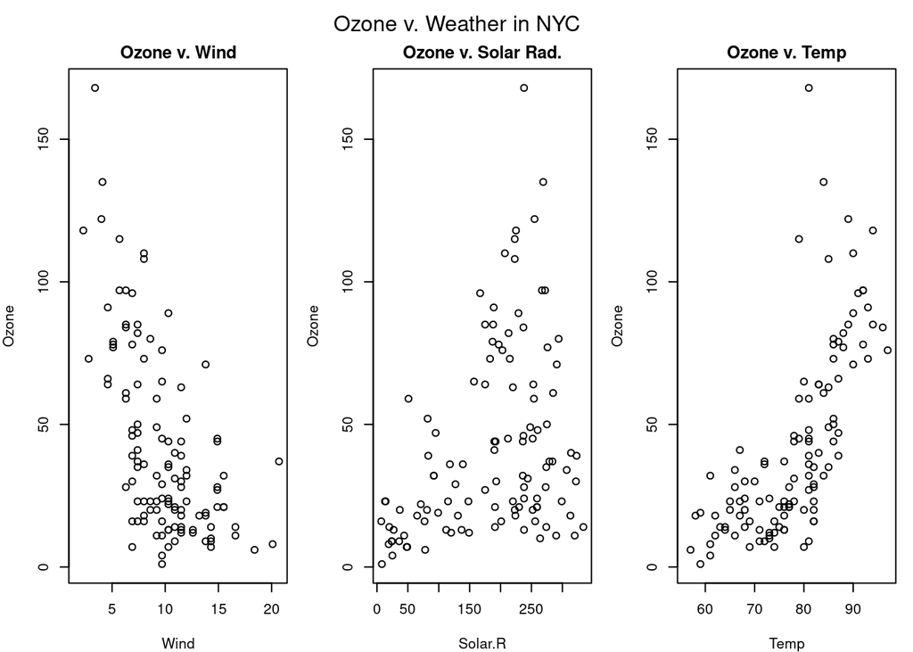

```r
library(datasets)

par(mfrow = c(1,3), mar = c(4,4,2,1), oma = c(0,0,2,0))
with(airquality, {
      plot(Wind, Ozone, main = "Ozone v. Wind")
      plot(Solar.R, Ozone, main = "Ozone v. Solar Rad.")
      plot(Temp, Ozone, main = "Ozone v. Temp")
      mtext("Ozone v. Weather in NYC", outer = TRUE)
}
)
```

### Base Plotting [Demonstration]

[Coursera7](https://www.coursera.org/learn/exploratory-data-analysis/lecture/yUFDH/base-plotting-demonstration)

- 4 margins; 1=Bottom, 2=left, 3=top, 4=right
  - par(mar = c(4,4,1,1))
- Add text to inside of plot
  - text(1,2, “label”)
- Add linear model
  - fit <- lm(y ~ x)
  - abline(fit)

```r
example(points)
```

```
##
## points> require(stats) # for rnorm
##
## points> plot(-4:4, -4:4, type = "n")  # setting up coord. system
```

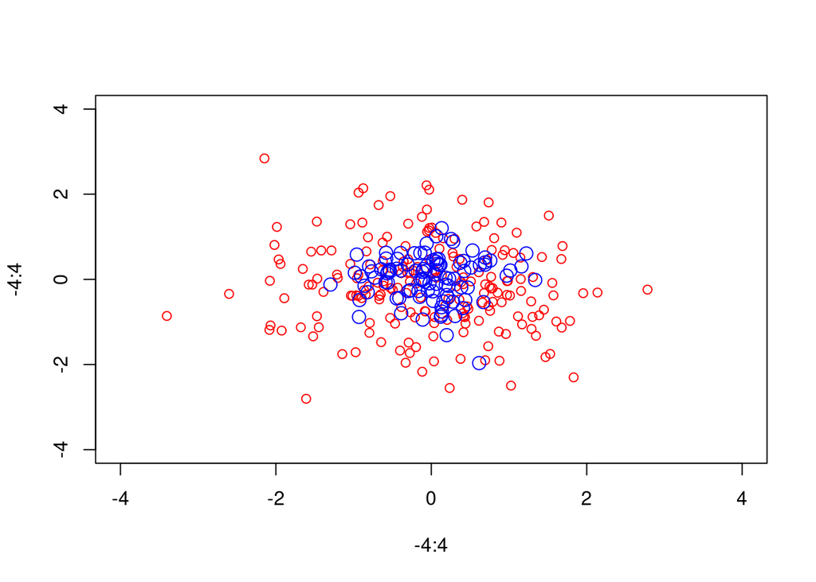

```
##
## points> points(rnorm(200), rnorm(200), col = "red")
##
## points> points(rnorm(100)/2, rnorm(100)/2, col = "blue", cex = 1.5)
##
## points> op <- par(bg = "light blue")
##
## points> x <- seq(0, 2*pi, len = 51)
##
## points> ## something "between type='b' and type='o'":
## points> plot(x, sin(x), type = "o", pch = 21, bg = par("bg"), col = "blue", cex = .6,
## points+  main = 'plot(..., type="o", pch=21, bg=par("bg"))')
```

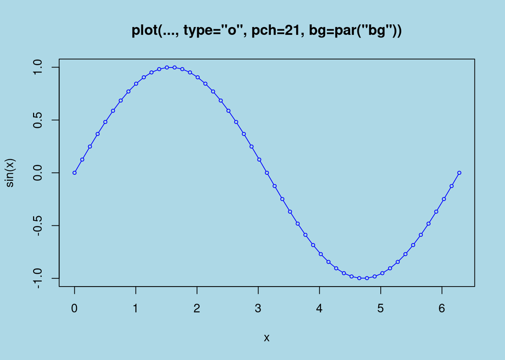

```
##
## points> par(op)
##
## points> ## Not run:
## points> ##D ## The figure was produced by calls like
## points> ##D png("pch.png", height = 0.7, width = 7, res = 100, units = "in")
## points> ##D par(mar = rep(0,4))
## points> ##D plot(c(-1, 26), 0:1, type = "n", axes = FALSE)
## points> ##D text(0:25, 0.6, 0:25, cex = 0.5)
## points> ##D points(0:25, rep(0.3, 26), pch = 0:25, bg = "grey")
## points> ## End(Not run)
## points>
## points> ##-------- Showing all the extra & some char graphics symbols ---------
## points> pchShow <-
## points+   function(extras = c("*",".", "o","O","0","+","-","|","%","#"),
## points+            cex = 3, ## good for both .Device=="postscript" and "x11"
## points+            col = "red3", bg = "gold", coltext = "brown", cextext = 1.2,
## points+            main = paste("plot symbols :  points (...  pch = *, cex =",
## points+                         cex,")"))
## points+   {
## points+     nex <- length(extras)
## points+     np  <- 26 + nex
## points+     ipch <- 0:(np-1)
## points+     k <- floor(sqrt(np))
## points+     dd <- c(-1,1)/2
## points+     rx <- dd + range(ix <- ipch %/% k)
## points+     ry <- dd + range(iy <- 3 + (k-1)- ipch %% k)
## points+     pch <- as.list(ipch) # list with integers & strings
## points+     if(nex > 0) pch[26+ 1:nex] <- as.list(extras)
## points+     plot(rx, ry, type = "n", axes  =  FALSE, xlab = "", ylab = "", main = main)
## points+     abline(v = ix, h = iy, col = "lightgray", lty = "dotted")
## points+     for(i in 1:np) {
## points+       pc <- pch[[i]]
## points+       ## 'col' symbols with a 'bg'-colored interior (where available) :
## points+       points(ix[i], iy[i], pch = pc, col = col, bg = bg, cex = cex)
## points+       if(cextext > 0)
## points+           text(ix[i] - 0.3, iy[i], pc, col = coltext, cex = cextext)
## points+     }
## points+   }
##
## points> pchShow()
```

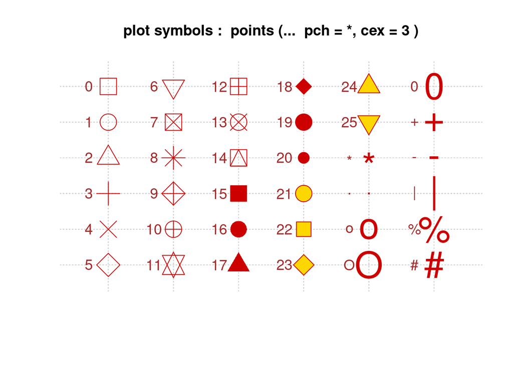

```
##
## points> pchShow(c("o","O","0"), cex = 2.5)
```

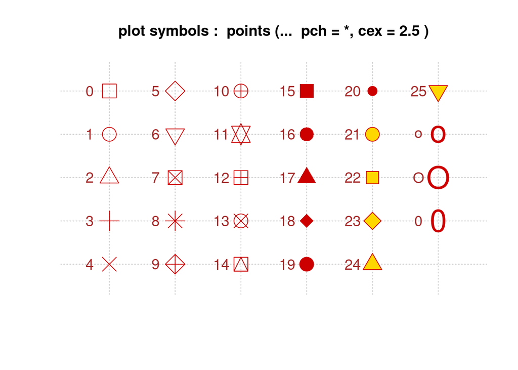

```
##
## points> pchShow(NULL, cex = 4, cextext = 0, main = NULL)
```

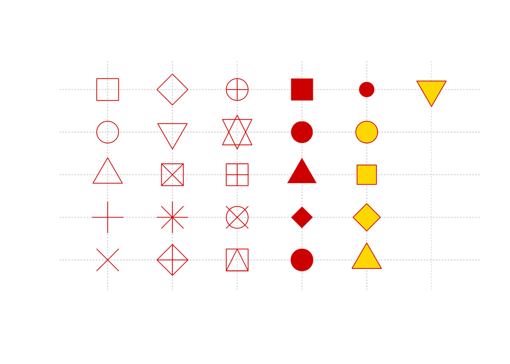

[output not shown]

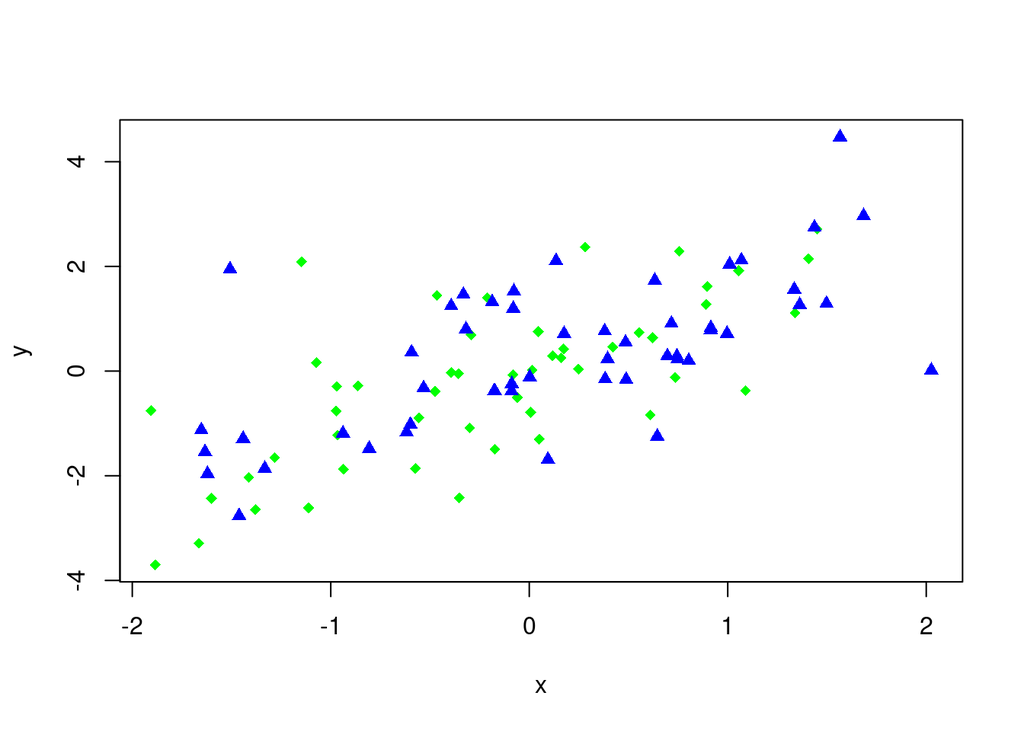

```r
x <- rnorm(100)
y <- x + rnorm(100)
g <- gl(2, 50, labels = c("male", "female"))

plot(x, y, type = "n")
points(x[g == "male"], y[g == "male"], col = "green", pch = 18)
points(x[g == "female"], y[g == "female"], col = "blue", pch = 17)
```

## Graphics Devices in R-Part 1

[Coursera8](https://www.coursera.org/learn/exploratory-data-analysis/lecture/DQ1md/graphics-devices-in-r-part-1)

A graphics device is an output device.

- Screen device, printer
- PDF, .png, .jpg, .svg, etc, file devices
- In Linux <- x11
- ?devices for info.
- **Example of device functions: plot, xyplot, gplot**

An other way to save plots is by opening a device; 1. Explicitly open a device, ex. pdf(file = file) 2. Call a plotting function, plot will not show on screen 3. Annotate plot if needed 4. Close or turn off device `dev.off()`

```r
pdf(file = "plot.pdf")
with(iris, plot(x, y))
title(main = "Title")
dev.off()
```

## Graphics Devices in R-Part 2

[Coursera9](https://www.coursera.org/learn/exploratory-data-analysis/lecture/W6KQs/graphics-devices-in-r-part-2)

Vector formats - pdf - svg - win.metafile (old windows only) - postscript

Bitmap format - png (lossless) - jpeg (lossy) - tiff (lossless) - bmp

### Opening multiple graphics devices

**Ploting can only occur on 1 graphics device at a time.**

- To find active device, USE: `dev.cur()`
- Every open graphics device is assigned an integer >= 2.
- Change active device; `dev.set(int)`

### Copying Plots

- `dev.copy` cp from one device to another
- `dev.copy2pdf` copy to pdf

Example

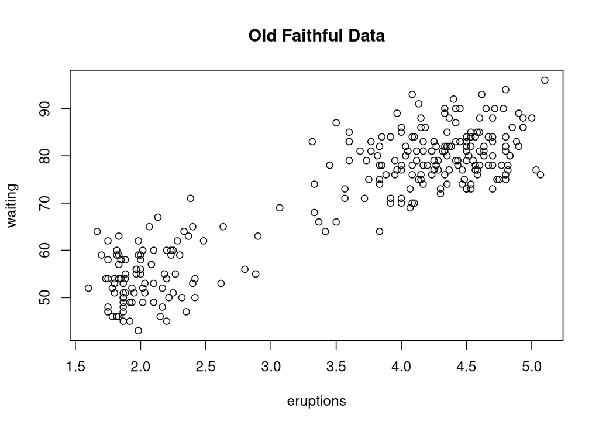

```r
library(datasets)

with(faithful, plot(eruptions, waiting))
title(main = "Old Faithful Data")
```

```r
dev.copy(png, file = "geyser_plot.png")
```

```r
dev.off()
```

1. Principles of Analytic Graphs
2. Exploratory Graphs
3. Graphics Devices in R
4. Plotting Systems
5. Base Plotting System